# Animal Form and Function (Part 1)

## Things to Know (#s)

**#Embryo Develop**

**#Germ/Tissue Layers**

**#Animal Body Plans**

## Animals are multi-cellular, eukaryotic heterotrophs

- **Must ingest organic materials**
  - consume, breakdown *internally* with enzymes
- **Lack structural support from cell walls**
  - extracellular proteins connect and strengthen cells
  - most abundant are *collagen* (not found in plants/fungi)
- **Cells organized into tissues for “True Animals”**
  - similar cells acting as a functional unit
  - muscle & nervous tissue allows animals to move
- **Body plan = programmed development driven by evolution**

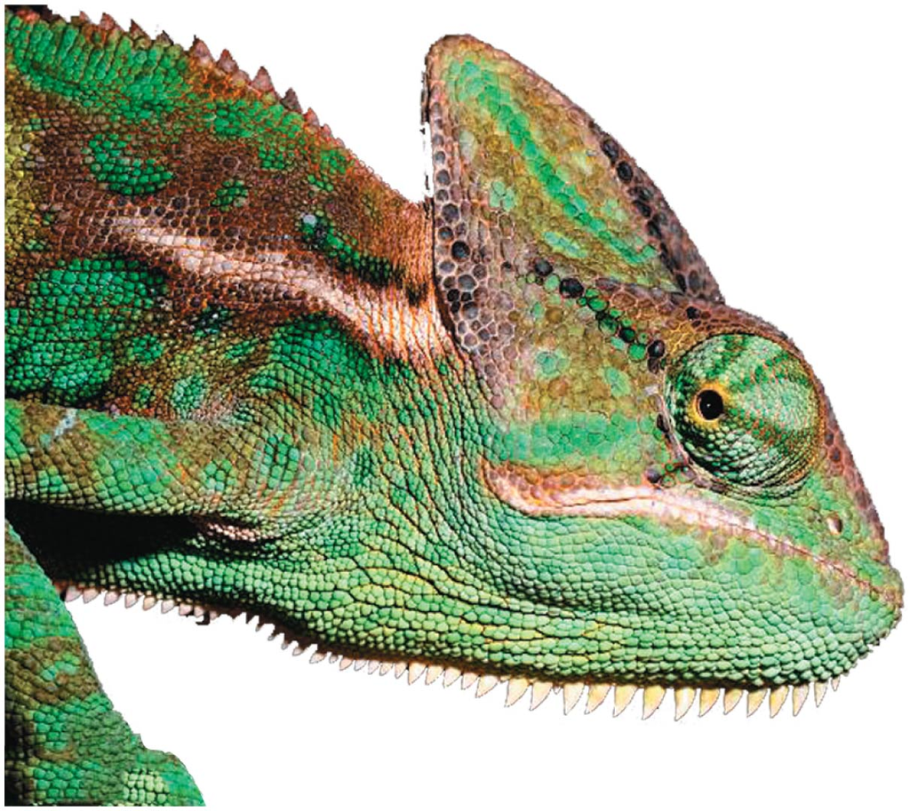

## Body plans are coordinated to optimize biological function

**Hox genes are a group of related genes that specify regions of the body plan of an embryo along the head-tail axis of animals**

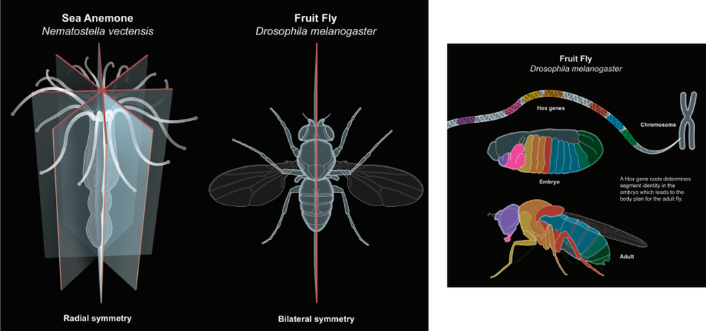

## Embryonic development key for animal diversity

[figure not shown]

- **Fertilized zygote undergoes cleavage**
  - mitotic cell divisions without cell growth
  - rapid division but overall size stays same
  - protostome vs *deuterostome* = alignment of these cells
- **Early multicellular stage called a blastula (hollow ball)**
- **Germ (tissue) layers develop in next stage (gastrulation)**
  - eventually develop into body parts
- **Many animals have a larval (post-embryo) and adult stage**
  - larva are sexually immature
  - larva look, live and eat differently

[figure not shown]

## Devlopment of the blastopore in different animal groups

[figure not shown]

- **Blastopore: opening of central cavity of an embryo**
- **In most animals a second opening forms at opposite end**
  - become openings of digestive tube
- **Diploblasts: opening to gastrovascular cavity**
- **Protostomes: blastopore becomes mouth**
- **Deuterostomes: blastopore becomes anus**

## Germ/tissue layers (primary cell layers in development)

- **Sponges (0), Diploblasts (2), Triploblasts (3)**
  - germ layers develop into tissues and organs
- **Ectoderm:**
- **Endoderm:**
- **Mesoderm:**

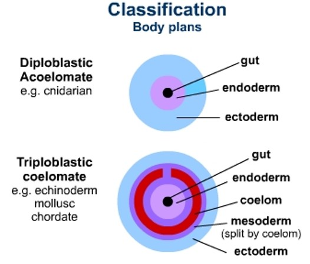

[figure not shown]

## Body Cavities in Triploblasts

- **Fluid/air spaces form within mesoderm layers**
  - digestive track and body wall
- **Body cavity called coelom**
  - cushions organs
  - fluid resistance for muscles
  - allows organs to move independently
- **Not all triploblasts have a coelom**

[figure not shown]

## Mammals develop subdivided body cavities from coelom

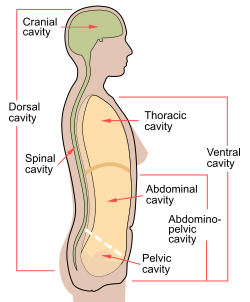

- **DONT memorize!!**
- **The dorsal cavity and the ventral cavity are the largest body compartments.**
- **Dorsal body cavity includes the cranial cavity, enclosed by the skull, and the spinal cavity, enclosed by the spine**
- **Ventral body cavity subdivided into 2 compartments**
  - thoracic contains the lungs and heart
  - abdominopelvic contains the kidneys, ureters, stomach, intestines, liver, gallbladder, pancreas, bladder, anus and reproductive system

## Evolution of animal size and shape

- **Animal body plans are expressions of the genome, but the product of millions of years of evolution**
- **Animals body plans are constrained by physical laws**
  - diffusion, size and movement, heat exchange
  - gravity (land), pressure (aquatic)
- **Example: Properties of water and animal shape**
  - water more dense than air = surface bumps cause drag
  - natural selection favored tapered smooth bodies
  - convergent selection across aquatic vertebrates

[figure not shown]

## Form and function in biology

[figure not shown]

## Example: Diversity of bird form is tremendous

[figure not shown]

## Movie monsters are mostly not possible…. Godzilla

- **At that size, Godzilla’s heart wouldn’t be able to pump blood to the brain**
- **Brain would send messages too slowly to muscles, so wouldn’t be able to move properly**
- **Godzilla would have to sunbath constantly to stay warm**

[figure not shown]

## Movie monsters and the square-cube law

- **Cube-square law: if you make an animal larger, the surface area increases by the square of the growth factor, while the volume (and mass) increases by the cube of that factor (huh?!?)**
  - *when an animal gets bigger, its weight/volume increases faster than its body surface*
- **You’re Gonna Need Thicc Legs**
  - support structures like bones and muscles must carry much more mass
  - leg size would have to scale up disproportionately, severely limiting movement
- **Movie monsters would not be able to run fast (too eat or fight heros), and would struggle to lose heat through their skin**
  - shooting fire from the mouth would actually be required

[figure not shown]

## Real large animals and the square-cube law

- **Elephants exist because they are slow, have uniform thick legs, have slow metabolism, and eat infrequently (grass)**
- **Large dinosaurs existed because they had stable environments with tons of food but likely represent the practical limit for land animals!!**
- **Large whales exist because its bouyancy reduces the effects of gravity. Water supports much of the body weight. On land, the whale’s mass would crush it.**

[figure not shown]

## Exchange with environment limits animal bodies

- **Required Animal Functions: uptake nutrients, expel waste and exchange gases**
  - occurs across plasma membrane of all cells
- **Simple internal body plan: Cnidarians (jellyfish)**
  - outer tissues exposed to environment
  - gastrovascular cavity also open to environment

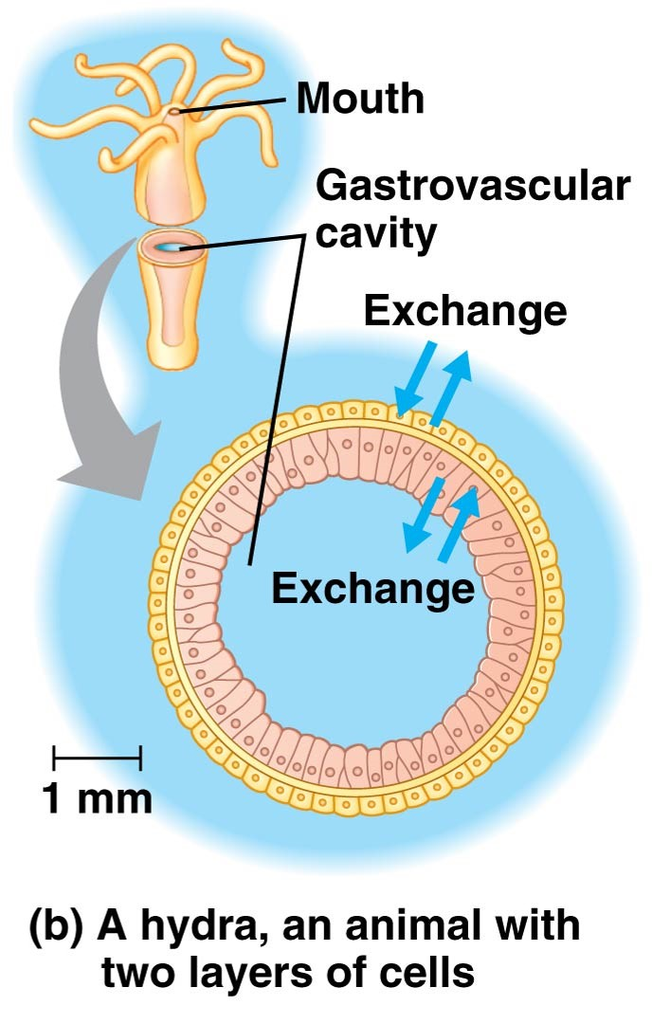

## Exchange with environment limits animal bodies

- **Required Animal Functions: uptake nutrients, expel waste and exchange gases**
  - occurs across plasma membrane of all cells
- **Body plan optimized for surface area: Flatworms**
  - thin, flat shape
  - lots of outer cells exposed to environment
  - gastrovascular cavity also open to environment

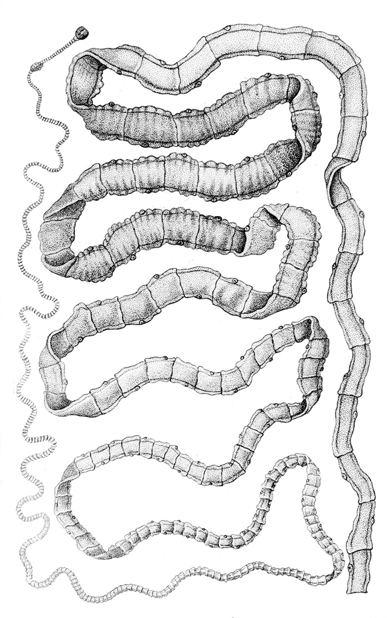

## Exchange with environment limits animal bodies

- **Required Animal Functions: uptake nutrients, expel waste and exchange gases**
  - occurs across plasma membrane of all cells
- **Many animals (like humans) have more complex internal bodies**
  - reduces total # of cells on outer surface
  - volume > surface area
  - ‘think’ whale versus flatworm
- **Internal structures for exchange evolved…**
  - highly branched or folded
  - e.g., lungs, intestines, kidneys

[figure not shown]

## Exchange with environment limits animal bodies

- **Required Animal Functions: uptake nutrients, expel waste and exchange gases**
  - occurs across plasma membrane of all cells
- **Many animals (like humans) have more complex internal bodies**
  - reduces total # of cells on outer surface
  - ‘think’ whale versus flatworm
- **Internal organs for exchange evolve…**
  - highly branched or folded
  - digestion, respiration and circulation
  - fluids connect structures to other cells

[figure not shown]

## What are the advantages of a complex body plan?

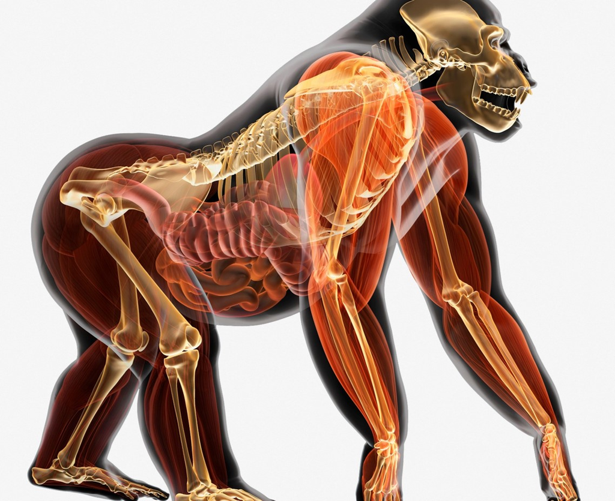

## Hierarchy of animal body plans

- **Cells with similar function grouped into tissues**
- **Different tissues organized into functional units: Organs**
- **Groups of organs can work together: Organ systems**
- **There are a limited set of tissues in animals**
1. *epithelial*:
2. *connective*:
3. *muscle*:
4. *nervous*:

[figure not shown]

[figure not shown]